# Workshop.4

```r
ggsave("my-plot.pdf")
```

Workshop 2 Assignment

```r
Qfish <-read.csv("../data/QFish_Data.csv")
print(Qfish)
```

```
##                                    Area X2001.Total
## 1                         Bribie Island           0
## 2                             Bundaberg          75
## 3                                Cairns         100
## 4                       Capricorn Coast          89
## 5                             Gladstone          32
## 6                            Gold Coast         155
## 7                                Mackay         172
## 8                    Nth Stradbroke Is.          26
## 9                         Rainbow Beach          44
## 10                 Sunshine Coast North         115
## 11                 Sunshine Coast South           0
## 12 Sunshine Coast South & Bribie Island          48
## 13                           Townsville         108
```

Plotting the data, it is mainly cleaned, there are no NAs or missing values

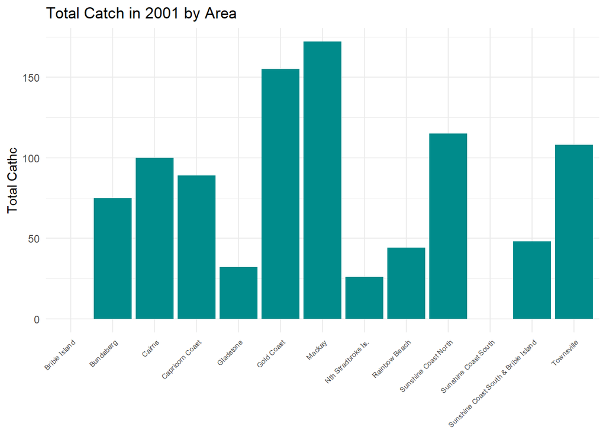

```r
library(ggplot2)
ggplot(Qfish, aes (x = Area, y = X2001.Total))+
  geom_bar(stat = "identity", fill = "darkcyan") +
  theme_minimal()+
  labs(title = "Total Catch in 2001 by Area",
       x = NULL,
       y = "Total Cathc") +
  theme(axis.text.x =element_text(angle = 45, hjust = 1, size = 6))
```

Workshop 3

```r
library(tidyverse)
table1
```

```
## # A tibble: 6 × 4
##   country      year  cases population
##   <chr>       <dbl>  <dbl>      <dbl>
## 1 Afghanistan  1999    745   19987071
## 2 Afghanistan  2000   2666   20595360
## 3 Brazil       1999  37737  172006362
## 4 Brazil       2000  80488  174504898
## 5 China        1999 212258 1272915272
## 6 China        2000 213766 1280428583
```

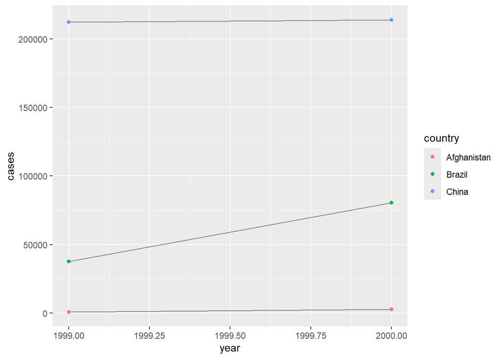

```r
library(ggplot2)
ggplot(table1, aes(year, cases))+
  geom_line(aes(group = country), colour = "grey50") +
  geom_point(aes(colour = country))
```

```r
table1
```

```
## # A tibble: 6 × 4
##   country      year  cases population
##   <chr>       <dbl>  <dbl>      <dbl>
## 1 Afghanistan  1999    745   19987071
## 2 Afghanistan  2000   2666   20595360
## 3 Brazil       1999  37737  172006362
## 4 Brazil       2000  80488  174504898
## 5 China        1999 212258 1272915272
## 6 China        2000 213766 1280428583
```

```r
table2
```

```
## # A tibble: 12 × 4
##    country      year type            count
##    <chr>       <dbl> <chr>           <dbl>
##  1 Afghanistan  1999 cases             745
##  2 Afghanistan  1999 population   19987071
##  3 Afghanistan  2000 cases            2666
##  4 Afghanistan  2000 population   20595360
##  5 Brazil       1999 cases           37737
##  6 Brazil       1999 population  172006362
##  7 Brazil       2000 cases           80488
##  8 Brazil       2000 population  174504898
##  9 China        1999 cases          212258
## 10 China        1999 population 1272915272
## 11 China        2000 cases          213766
## 12 China        2000 population 1280428583
```

```r
table3
```

```
## # A tibble: 6 × 3
##   country      year rate
##   <chr>       <dbl> <chr>
## 1 Afghanistan  1999 745/19987071
## 2 Afghanistan  2000 2666/20595360
## 3 Brazil       1999 37737/172006362
## 4 Brazil       2000 80488/174504898
## 5 China        1999 212258/1272915272
## 6 China        2000 213766/1280428583
```

1. Table 1 is set up well with country, year cases and population. This shows the population per year per country with the number of cases. table2 shows the count of cases and population in each country separated by year. table3 has the rate in there but as the growth rate per year in each country but it has not been calculated yet.
2. 1. using table 1 we would use a combination of the pipe function and the pivot longer to call the cases with country and year because there are 2 years for each country. and use the mutate function to put it into a new row in the table
2. and then to do the matching population per country per year, we would do the same as above but instead of case it would be population and then would mutate it so that it created a new row in the chart
3. using those new columns and creating a new column I can then calculate the the case by population and multiply it by 10,000 and use the mutate function to put that back into the dataset.

```r
billboard |>
  pivot_longer(
    cols = starts_with("wk"),
    names_to = "week",
    values_to = "rank",
    values_drop_na = TRUE
  )
```

```
## # A tibble: 5,307 × 5
##    artist  track                   date.entered week   rank
##    <chr>   <chr>                   <date>       <chr> <dbl>
##  1 2 Pac   Baby Don't Cry (Keep... 2000-02-26   wk1      87
##  2 2 Pac   Baby Don't Cry (Keep... 2000-02-26   wk2      82
##  3 2 Pac   Baby Don't Cry (Keep... 2000-02-26   wk3      72
##  4 2 Pac   Baby Don't Cry (Keep... 2000-02-26   wk4      77
##  5 2 Pac   Baby Don't Cry (Keep... 2000-02-26   wk5      87
##  6 2 Pac   Baby Don't Cry (Keep... 2000-02-26   wk6      94
##  7 2 Pac   Baby Don't Cry (Keep... 2000-02-26   wk7      99
##  8 2Ge+her The Hardest Part Of ... 2000-09-02   wk1      91
##  9 2Ge+her The Hardest Part Of ... 2000-09-02   wk2      87
## 10 2Ge+her The Hardest Part Of ... 2000-09-02   wk3      92
## # ℹ 5,297 more rows
```

```r
df <- tribble (
  ~id, ~bp1, ~bp2,
  "A", 100, 120,
  "B", 140, 115,
  "C", 120, 125
)
#this is creating out own dataset called df with 3 variables

df|>
  pivot_longer(
    cols = bp1:bp2,
    names_to = "measurement",
    values_to ="value"
  )
```

```
## # A tibble: 6 × 3
##   id    measurement value
##   <chr> <chr>       <dbl>
## 1 A     bp1           100
## 2 A     bp2           120
## 3 B     bp1           140
## 4 B     bp2           115
## 5 C     bp1           120
## 6 C     bp2           125
```

```r
#the above took the values for both bp1 and bp2 into one column and then another column was its matched bp1 or bp2
```

```r
cms_patient_experience |>
  pivot_wider(
    id_cols = starts_with("org"),
    names_from = measure_cd,
    values_from = prf_rate
  )
```

```
## # A tibble: 95 × 8
##    org_pac_id org_nm CAHPS_GRP_1 CAHPS_GRP_2 CAHPS_GRP_3 CAHPS_GRP_5 CAHPS_GRP_8
##    <chr>      <chr>        <dbl>       <dbl>       <dbl>       <dbl>       <dbl>
##  1 0446157747 USC C…          63          87          86          57          85
##  2 0446162697 ASSOC…          59          85          83          63          88
##  3 0547164295 BEAVE…          49          NA          75          44          73
##  4 0749333730 CAPE …          67          84          85          65          82
##  5 0840104360 ALLIA…          66          87          87          64          87
##  6 0840109864 REX H…          73          87          84          67          91
##  7 0840513552 SCL H…          58          83          76          58          78
##  8 0941545784 GRITM…          46          86          81          54          NA
##  9 1052612785 COMMU…          65          84          80          58          87
## 10 1254237779 OUR L…          61          NA          NA          65          NA
## # ℹ 85 more rows
## # ℹ 1 more variable: CAHPS_GRP_12 <dbl>
```

```r
df <- tribble (
  ~id, ~measurement, ~value,
  "A", "bp1", 100,
  "B", "bp2", 115,
  "B", "bp1", 140,
  "A", "bp2", 120,
  "A", "bp3", 105
)
print(df)
```

```
## # A tibble: 5 × 3
##   id    measurement value
##   <chr> <chr>       <dbl>
## 1 A     bp1           100
## 2 B     bp2           115
## 3 B     bp1           140
## 4 A     bp2           120
## 5 A     bp3           105
```

```r
df |>
  pivot_wider(
    names_from = measurement,
    values_from = value
  )
```

```
## # A tibble: 2 × 4
##   id      bp1   bp2   bp3
##   <chr> <dbl> <dbl> <dbl>
## 1 A       100   120   105
## 2 B       140   115    NA
```

```r
df |>
  distinct (measurement) |>
  pull()
```

```
## [1] "bp1" "bp2" "bp3"
```

```r
df |>
  select(-measurement, -value) |>
  distinct()|>
  mutate(x = NA, y = NA, z = NA)
```

```
## # A tibble: 2 × 4
##   id    x     y     z
##   <chr> <lgl> <lgl> <lgl>
## 1 A     NA    NA    NA
## 2 B     NA    NA    NA
```

Excercise 4.5.5

```r
stocks <- tibble(
  year = c(2015, 2015, 2016, 2016),
  half = c(1, 2, 1, 2),
  return = c(1.88, 0.59, 0.92, 0.17)
)

stocks %>%
  pivot_wider(names_from = year, values_from = return) %>%
  pivot_longer('2015':'2016',names_to = "year", values_to = "return")
```

```
## # A tibble: 4 × 3
##    half year  return
##   <dbl> <chr>  <dbl>
## 1     1 2015    1.88
## 2     1 2016    0.92
## 3     2 2015    0.59
## 4     2 2016    0.17
```

1. it is becuase they sort the data differently. One organizes by 1/2 1 na dthe other by 1/2 2
2. the code fails because the years need the quotations around them
3. this tibble would need to be longer. the variables are pregnant, male and female

```r
table3 |>
  separate(rate, into = c("cases", "population"), convert = TRUE)
```

```
## # A tibble: 6 × 4
##   country      year  cases population
##   <chr>       <dbl>  <int>      <int>
## 1 Afghanistan  1999    745   19987071
## 2 Afghanistan  2000   2666   20595360
## 3 Brazil       1999  37737  172006362
## 4 Brazil       2000  80488  174504898
## 5 China        1999 212258 1272915272
## 6 China        2000 213766 1280428583
```

```r
table3 |>
  separate(year, into = c("century", "year"), sep = 2)
```

```
## # A tibble: 6 × 4
##   country     century year  rate
##   <chr>       <chr>   <chr> <chr>
## 1 Afghanistan 19      99    745/19987071
## 2 Afghanistan 20      00    2666/20595360
## 3 Brazil      19      99    37737/172006362
## 4 Brazil      20      00    80488/174504898
## 5 China       19      99    212258/1272915272
## 6 China       20      00    213766/1280428583
```

```r
table5|>
  unite(new,century,year,sep = "")
```

```
## # A tibble: 6 × 3
##   country     new   rate
##   <chr>       <chr> <chr>
## 1 Afghanistan 1999  745/19987071
## 2 Afghanistan 2000  2666/20595360
## 3 Brazil      1999  37737/172006362
## 4 Brazil      2000  80488/174504898
## 5 China       1999  212258/1272915272
## 6 China       2000  213766/1280428583
```

```r
treatment <- tribble(
  ~person, ~treatment, ~response,
  "Derrick", 1, 7,
  NA, 2, 10,
  NA, 3, NA,
  "Katherine", 1, 4
)

#you can use fill in these missing values with tidyr::fill(), it works like select()
treatment |>
  fill(everything())
```

```
## # A tibble: 4 × 3
##   person    treatment response
##   <chr>         <dbl>    <dbl>
## 1 Derrick           1        7
## 2 Derrick           2       10
## 3 Derrick           3       10
## 4 Katherine         1        4
```

```r
#this treatment is sometimes calles "last observation carried forward"
```

```r
x <- c(1,4,5,7,NA)
coalesce(x,0)
```

```
## [1] 1 4 5 7 0
```

```r
x <- c(1,4,5,7,-99)
na_if(x,-99)
```

```
## [1]  1  4  5  7 NA
```

```r
x<- c (NA, NaN)
x*10
```

```
## [1]  NA NaN
```

```r
x==1
```

```
## [1] NA NA
```

```r
is.na(x)
```

```
## [1] TRUE TRUE
```

```r
stocks <- tibble(
  year = c(2020,2020,2020,2020,2021,2021,2021),
  qrt = c(1,2,3,4,2,3,4),
  price = c(1.88,0.59,0.35,NA,0.92,0.17,2.66)
)

stocks |>
  pivot_wider(
    names_from = qrt,
    values_from = price
  )
```

```
## # A tibble: 2 × 5
##    year   `1`   `2`   `3`   `4`
##   <dbl> <dbl> <dbl> <dbl> <dbl>
## 1  2020  1.88  0.59  0.35 NA
## 2  2021 NA     0.92  0.17  2.66
```

```r
students <- read_csv("https://pos.it/r4ds-students-csv", na=c("N/A", "")) #this brings in a csv file from the internet
#The N/A is not recognised as an actual NA so we converted it so that it does
students
```

```
## # A tibble: 6 × 5
##   `Student ID` `Full Name`      favourite.food     mealPlan            AGE
##          <dbl> <chr>            <chr>              <chr>               <chr>
## 1            1 Sunil Huffmann   Strawberry yoghurt Lunch only          4
## 2            2 Barclay Lynn     French fries       Lunch only          5
## 3            3 Jayendra Lyne    <NA>               Breakfast and lunch 7
## 4            4 Leon Rossini     Anchovies          Lunch only          <NA>
## 5            5 Chidiegwu Dunkel Pizza              Breakfast and lunch five
## 6            6 Güvenç Attila    Ice cream          Lunch only          6
```

```r
students |>
  rename(
    student_id = 'Student ID',
    full_name = 'Full Name'
         )
```

```
## # A tibble: 6 × 5
##   student_id full_name        favourite.food     mealPlan            AGE
##        <dbl> <chr>            <chr>              <chr>               <chr>
## 1          1 Sunil Huffmann   Strawberry yoghurt Lunch only          4
## 2          2 Barclay Lynn     French fries       Lunch only          5
## 3          3 Jayendra Lyne    <NA>               Breakfast and lunch 7
## 4          4 Leon Rossini     Anchovies          Lunch only          <NA>
## 5          5 Chidiegwu Dunkel Pizza              Breakfast and lunch five
## 6          6 Güvenç Attila    Ice cream          Lunch only          6
```

Exercise 4.7.3

1. each of these are creating a file.
2. there are not enough column names
3. there are too many rows for the amount of columns present
4. there is a quotation issue with this one
5. there is an issue with number and character
6. the last one needs a comma not a semicolon

```r
library(tidyverse)
#install.packages("nycflights13")
library(nycflights13)

airlines
```

```
## # A tibble: 16 × 2
##    carrier name
##    <chr>   <chr>
##  1 9E      Endeavor Air Inc.
##  2 AA      American Airlines Inc.
##  3 AS      Alaska Airlines Inc.
##  4 B6      JetBlue Airways
##  5 DL      Delta Air Lines Inc.
##  6 EV      ExpressJet Airlines Inc.
##  7 F9      Frontier Airlines Inc.
##  8 FL      AirTran Airways Corporation
##  9 HA      Hawaiian Airlines Inc.
## 10 MQ      Envoy Air
## 11 OO      SkyWest Airlines Inc.
## 12 UA      United Air Lines Inc.
## 13 US      US Airways Inc.
## 14 VX      Virgin America
## 15 WN      Southwest Airlines Co.
## 16 YV      Mesa Airlines Inc.
```

```r
airports
```

```
## # A tibble: 1,458 × 8
##    faa   name                             lat    lon   alt    tz dst   tzone
##    <chr> <chr>                          <dbl>  <dbl> <dbl> <dbl> <chr> <chr>
##  1 04G   Lansdowne Airport               41.1  -80.6  1044    -5 A     America/…
##  2 06A   Moton Field Municipal Airport   32.5  -85.7   264    -6 A     America/…
##  3 06C   Schaumburg Regional             42.0  -88.1   801    -6 A     America/…
##  4 06N   Randall Airport                 41.4  -74.4   523    -5 A     America/…
##  5 09J   Jekyll Island Airport           31.1  -81.4    11    -5 A     America/…
##  6 0A9   Elizabethton Municipal Airport  36.4  -82.2  1593    -5 A     America/…
##  7 0G6   Williams County Airport         41.5  -84.5   730    -5 A     America/…
##  8 0G7   Finger Lakes Regional Airport   42.9  -76.8   492    -5 A     America/…
##  9 0P2   Shoestring Aviation Airfield    39.8  -76.6  1000    -5 U     America/…
## 10 0S9   Jefferson County Intl           48.1 -123.    108    -8 A     America/…
## # ℹ 1,448 more rows
```

```r
planes
```

```
## # A tibble: 3,322 × 9
##    tailnum  year type              manufacturer model engines seats speed engine
##    <chr>   <int> <chr>             <chr>        <chr>   <int> <int> <int> <chr>
##  1 N10156   2004 Fixed wing multi… EMBRAER      EMB-…       2    55    NA Turbo…
##  2 N102UW   1998 Fixed wing multi… AIRBUS INDU… A320…       2   182    NA Turbo…
##  3 N103US   1999 Fixed wing multi… AIRBUS INDU… A320…       2   182    NA Turbo…
##  4 N104UW   1999 Fixed wing multi… AIRBUS INDU… A320…       2   182    NA Turbo…
##  5 N10575   2002 Fixed wing multi… EMBRAER      EMB-…       2    55    NA Turbo…
##  6 N105UW   1999 Fixed wing multi… AIRBUS INDU… A320…       2   182    NA Turbo…
##  7 N107US   1999 Fixed wing multi… AIRBUS INDU… A320…       2   182    NA Turbo…
##  8 N108UW   1999 Fixed wing multi… AIRBUS INDU… A320…       2   182    NA Turbo…
##  9 N109UW   1999 Fixed wing multi… AIRBUS INDU… A320…       2   182    NA Turbo…
## 10 N110UW   1999 Fixed wing multi… AIRBUS INDU… A320…       2   182    NA Turbo…
## # ℹ 3,312 more rows
```

```r
weather
```

```
## # A tibble: 26,115 × 15
##    origin  year month   day  hour  temp  dewp humid wind_dir wind_speed
##    <chr>  <int> <int> <int> <int> <dbl> <dbl> <dbl>    <dbl>      <dbl>
##  1 EWR     2013     1     1     1  39.0  26.1  59.4      270      10.4
##  2 EWR     2013     1     1     2  39.0  27.0  61.6      250       8.06
##  3 EWR     2013     1     1     3  39.0  28.0  64.4      240      11.5
##  4 EWR     2013     1     1     4  39.9  28.0  62.2      250      12.7
##  5 EWR     2013     1     1     5  39.0  28.0  64.4      260      12.7
##  6 EWR     2013     1     1     6  37.9  28.0  67.2      240      11.5
##  7 EWR     2013     1     1     7  39.0  28.0  64.4      240      15.0
##  8 EWR     2013     1     1     8  39.9  28.0  62.2      250      10.4
##  9 EWR     2013     1     1     9  39.9  28.0  62.2      260      15.0
## 10 EWR     2013     1     1    10  41    28.0  59.6      260      13.8
## # ℹ 26,105 more rows
## # ℹ 5 more variables: wind_gust <dbl>, precip <dbl>, pressure <dbl>,
## #   visib <dbl>, time_hour <dttm>
```

#we are going to join the datasets, first we have to make tibbles of all of the data that we want from each dataset

```r
planes |>
  count(tailnum) |>
  filter(n>1)
```

```
## # A tibble: 0 × 2
## # ℹ 2 variables: tailnum <chr>, n <int>
```

```r
weather |>
  count(year,month,day,hour,origin)|>
  filter(n>1)
```

```
## # A tibble: 3 × 6
##    year month   day  hour origin     n
##   <int> <int> <int> <int> <chr>  <int>
## 1  2013    11     3     1 EWR        2
## 2  2013    11     3     1 JFK        2
## 3  2013    11     3     1 LGA        2
```

```r
flights |>
  count(year,month,day,flight) |>
  filter(n>1)
```

```
## # A tibble: 29,768 × 5
##     year month   day flight     n
##    <int> <int> <int>  <int> <int>
##  1  2013     1     1      1     2
##  2  2013     1     1      3     2
##  3  2013     1     1      4     2
##  4  2013     1     1     11     3
##  5  2013     1     1     15     2
##  6  2013     1     1     21     2
##  7  2013     1     1     27     4
##  8  2013     1     1     31     2
##  9  2013     1     1     32     2
## 10  2013     1     1     35     2
## # ℹ 29,758 more rows
```

```r
flights |>
  count(year,month,day,tailnum) |>
  filter(n>1)
```

```
## # A tibble: 64,928 × 5
##     year month   day tailnum     n
##    <int> <int> <int> <chr>   <int>
##  1  2013     1     1 N0EGMQ      2
##  2  2013     1     1 N11189      2
##  3  2013     1     1 N11536      2
##  4  2013     1     1 N11544      3
##  5  2013     1     1 N11551      2
##  6  2013     1     1 N12540      2
##  7  2013     1     1 N12567      2
##  8  2013     1     1 N13123      2
##  9  2013     1     1 N13538      3
## 10  2013     1     1 N13566      3
## # ℹ 64,918 more rows
```

then we are going to use mutating joins which adds variables to the right side of the sata table

```r
flights2 <- flights |>
  select(year:day,hour,origin,dest,tailnum,carrier)
flights2
```

```
## # A tibble: 336,776 × 8
##     year month   day  hour origin dest  tailnum carrier
##    <int> <int> <int> <dbl> <chr>  <chr> <chr>   <chr>
##  1  2013     1     1     5 EWR    IAH   N14228  UA
##  2  2013     1     1     5 LGA    IAH   N24211  UA
##  3  2013     1     1     5 JFK    MIA   N619AA  AA
##  4  2013     1     1     5 JFK    BQN   N804JB  B6
##  5  2013     1     1     6 LGA    ATL   N668DN  DL
##  6  2013     1     1     5 EWR    ORD   N39463  UA
##  7  2013     1     1     6 EWR    FLL   N516JB  B6
##  8  2013     1     1     6 LGA    IAD   N829AS  EV
##  9  2013     1     1     6 JFK    MCO   N593JB  B6
## 10  2013     1     1     6 LGA    ORD   N3ALAA  AA
## # ℹ 336,766 more rows
```

```r
flights2 |>
  select(-origin, -dest) |>
  left_join(airlines, by = "carrier")
```

```
## # A tibble: 336,776 × 7
##     year month   day  hour tailnum carrier name
##    <int> <int> <int> <dbl> <chr>   <chr>   <chr>
##  1  2013     1     1     5 N14228  UA      United Air Lines Inc.
##  2  2013     1     1     5 N24211  UA      United Air Lines Inc.
##  3  2013     1     1     5 N619AA  AA      American Airlines Inc.
##  4  2013     1     1     5 N804JB  B6      JetBlue Airways
##  5  2013     1     1     6 N668DN  DL      Delta Air Lines Inc.
##  6  2013     1     1     5 N39463  UA      United Air Lines Inc.
##  7  2013     1     1     6 N516JB  B6      JetBlue Airways
##  8  2013     1     1     6 N829AS  EV      ExpressJet Airlines Inc.
##  9  2013     1     1     6 N593JB  B6      JetBlue Airways
## 10  2013     1     1     6 N3ALAA  AA      American Airlines Inc.
## # ℹ 336,766 more rows
```

```r
flights2 |>
  select(-origin, -dest) |>
  mutate(name=airlines$name[match(carrier, airlines$carrier)])
```

```
## # A tibble: 336,776 × 7
##     year month   day  hour tailnum carrier name
##    <int> <int> <int> <dbl> <chr>   <chr>   <chr>
##  1  2013     1     1     5 N14228  UA      United Air Lines Inc.
##  2  2013     1     1     5 N24211  UA      United Air Lines Inc.
##  3  2013     1     1     5 N619AA  AA      American Airlines Inc.
##  4  2013     1     1     5 N804JB  B6      JetBlue Airways
##  5  2013     1     1     6 N668DN  DL      Delta Air Lines Inc.
##  6  2013     1     1     5 N39463  UA      United Air Lines Inc.
##  7  2013     1     1     6 N516JB  B6      JetBlue Airways
##  8  2013     1     1     6 N829AS  EV      ExpressJet Airlines Inc.
##  9  2013     1     1     6 N593JB  B6      JetBlue Airways
## 10  2013     1     1     6 N3ALAA  AA      American Airlines Inc.
## # ℹ 336,766 more rows
```

```r
x <- tribble(
  ~key, ~val_x,
  1, "x1",
  2, "x2",
  3, "x3"
)

y <- tribble(
  ~key, ~val_y,
  1, "y1",
  2, "2",
  3, "y3"
)


x |>
  inner_join(y, by = "key")
```

```
## # A tibble: 3 × 3
##     key val_x val_y
##   <dbl> <chr> <chr>
## 1     1 x1    y1
## 2     2 x2    2
## 3     3 x3    y3
```

```r
#left join: keeps all observations in x
#right join: keeps all observations in y
# full join: keeps all observations in x and y
```

```r
flights2 |>
  left_join(weather)
```

```
## # A tibble: 336,776 × 18
##     year month   day  hour origin dest  tailnum carrier  temp  dewp humid
##    <int> <int> <int> <dbl> <chr>  <chr> <chr>   <chr>   <dbl> <dbl> <dbl>
##  1  2013     1     1     5 EWR    IAH   N14228  UA       39.0  28.0  64.4
##  2  2013     1     1     5 LGA    IAH   N24211  UA       39.9  25.0  54.8
##  3  2013     1     1     5 JFK    MIA   N619AA  AA       39.0  27.0  61.6
##  4  2013     1     1     5 JFK    BQN   N804JB  B6       39.0  27.0  61.6
##  5  2013     1     1     6 LGA    ATL   N668DN  DL       39.9  25.0  54.8
##  6  2013     1     1     5 EWR    ORD   N39463  UA       39.0  28.0  64.4
##  7  2013     1     1     6 EWR    FLL   N516JB  B6       37.9  28.0  67.2
##  8  2013     1     1     6 LGA    IAD   N829AS  EV       39.9  25.0  54.8
##  9  2013     1     1     6 JFK    MCO   N593JB  B6       37.9  27.0  64.3
## 10  2013     1     1     6 LGA    ORD   N3ALAA  AA       39.9  25.0  54.8
## # ℹ 336,766 more rows
## # ℹ 7 more variables: wind_dir <dbl>, wind_speed <dbl>, wind_gust <dbl>,
## #   precip <dbl>, pressure <dbl>, visib <dbl>, time_hour <dttm>
```

```r
flights2 |>
  left_join(planes, by = "tailnum")
```

```
## # A tibble: 336,776 × 16
##    year.x month   day  hour origin dest  tailnum carrier year.y type
##     <int> <int> <int> <dbl> <chr>  <chr> <chr>   <chr>    <int> <chr>
##  1   2013     1     1     5 EWR    IAH   N14228  UA        1999 Fixed wing mult…
##  2   2013     1     1     5 LGA    IAH   N24211  UA        1998 Fixed wing mult…
##  3   2013     1     1     5 JFK    MIA   N619AA  AA        1990 Fixed wing mult…
##  4   2013     1     1     5 JFK    BQN   N804JB  B6        2012 Fixed wing mult…
##  5   2013     1     1     6 LGA    ATL   N668DN  DL        1991 Fixed wing mult…
##  6   2013     1     1     5 EWR    ORD   N39463  UA        2012 Fixed wing mult…
##  7   2013     1     1     6 EWR    FLL   N516JB  B6        2000 Fixed wing mult…
##  8   2013     1     1     6 LGA    IAD   N829AS  EV        1998 Fixed wing mult…
##  9   2013     1     1     6 JFK    MCO   N593JB  B6        2004 Fixed wing mult…
## 10   2013     1     1     6 LGA    ORD   N3ALAA  AA          NA <NA>
## # ℹ 336,766 more rows
## # ℹ 6 more variables: manufacturer <chr>, model <chr>, engines <int>,
## #   seats <int>, speed <int>, engine <chr>
```

```r
flights2 |>
  left_join(airports, c("dest"= "faa"))
```

```
## # A tibble: 336,776 × 15
##     year month   day  hour origin dest  tailnum carrier name     lat   lon   alt
##    <int> <int> <int> <dbl> <chr>  <chr> <chr>   <chr>   <chr>  <dbl> <dbl> <dbl>
##  1  2013     1     1     5 EWR    IAH   N14228  UA      Georg…  30.0 -95.3    97
##  2  2013     1     1     5 LGA    IAH   N24211  UA      Georg…  30.0 -95.3    97
##  3  2013     1     1     5 JFK    MIA   N619AA  AA      Miami…  25.8 -80.3     8
##  4  2013     1     1     5 JFK    BQN   N804JB  B6      <NA>    NA    NA      NA
##  5  2013     1     1     6 LGA    ATL   N668DN  DL      Harts…  33.6 -84.4  1026
##  6  2013     1     1     5 EWR    ORD   N39463  UA      Chica…  42.0 -87.9   668
##  7  2013     1     1     6 EWR    FLL   N516JB  B6      Fort …  26.1 -80.2     9
##  8  2013     1     1     6 LGA    IAD   N829AS  EV      Washi…  38.9 -77.5   313
##  9  2013     1     1     6 JFK    MCO   N593JB  B6      Orlan…  28.4 -81.3    96
## 10  2013     1     1     6 LGA    ORD   N3ALAA  AA      Chica…  42.0 -87.9   668
## # ℹ 336,766 more rows
## # ℹ 3 more variables: tz <dbl>, dst <chr>, tzone <chr>
```

Workshop 4: Spatial data

```r
#install.packages("sf")
#install.packages("terra")
#install.packages("tmap")

library(sf) #simple features
library(terra) #for raster
```

```r
library(tmap) #thematic maps are geographical maps in whcih spatial data distributions are visualized
library(tidyverse)
library(readr)
```

```r
dat <- read_csv("C:/Users/sydne/OneDrive - James Cook University/Documents/JCU/MB5370/github/SR-Code/Module04_SR/data/data-for-course/copepods_raw.csv")
dat
```

```
## # A tibble: 5,313 × 11
##    silk_id segment_no latitude longitude sample_time_utc  project route vessel
##      <dbl>      <dbl>    <dbl>     <dbl> <chr>            <chr>   <chr> <chr>
##  1       1          1    -28.3      154. 26/06/2009 22:08 AusCPR  BRSY  ANL Win…
##  2       1          5    -28.7      154. 26/06/2009 23:12 AusCPR  BRSY  ANL Win…
##  3       1          9    -29.0      154. 27/06/2009 0:17  AusCPR  BRSY  ANL Win…
##  4       1         13    -29.3      154. 27/06/2009 1:22  AusCPR  BRSY  ANL Win…
##  5       1         17    -29.7      154. 27/06/2009 2:26  AusCPR  BRSY  ANL Win…
##  6       1         18    -29.8      154. 27/06/2009 2:43  AusCPR  BRSY  ANL Win…
##  7       1         26    -30.4      153. 27/06/2009 4:52  AusCPR  BRSY  ANL Win…
##  8       1         30    -30.7      153. 27/06/2009 5:57  AusCPR  BRSY  ANL Win…
##  9       1         33    -31.0      153. 27/06/2009 6:45  AusCPR  BRSY  ANL Win…
## 10       1         37    -31.3      153. 27/06/2009 7:50  AusCPR  BRSY  ANL Win…
## # ℹ 5,303 more rows
## # ℹ 3 more variables: meanlong <dbl>, region <chr>, richness_raw <dbl>
```

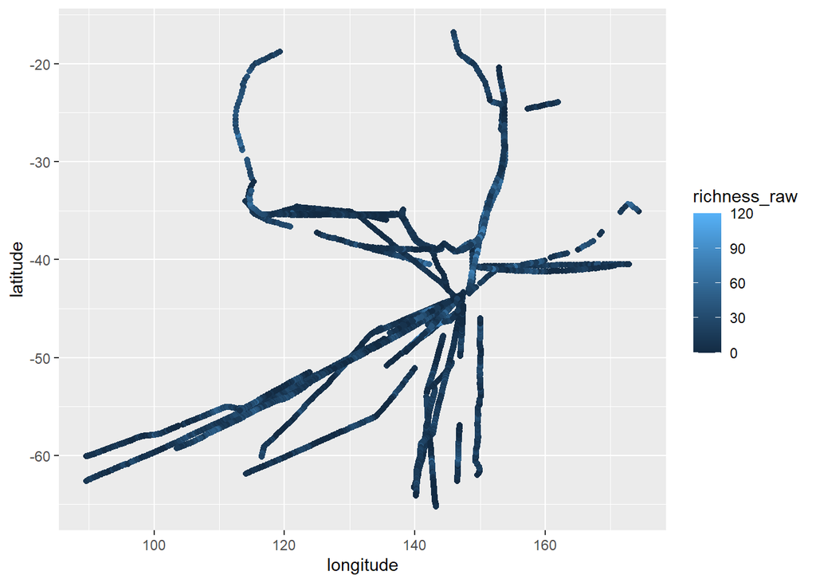

```r
library(ggplot2)

ggplot(dat)+
  aes(x=longitude,y=latitude, color=richness_raw)+
  geom_point()
```

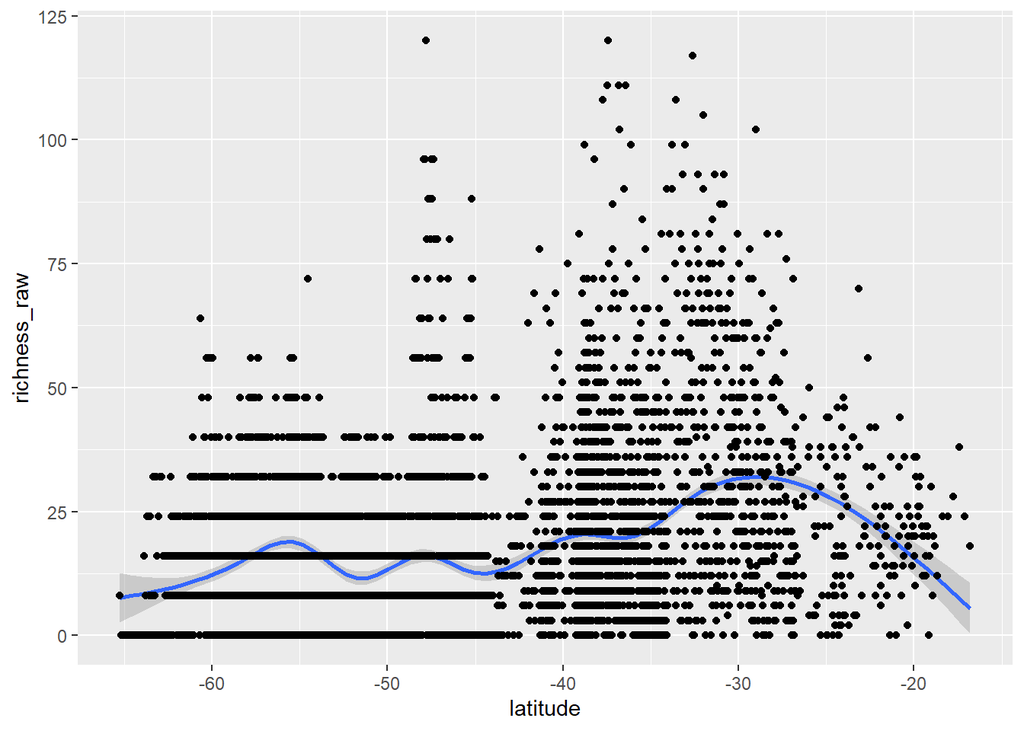

```r
ggplot(dat, aes(x = latitude, y = richness_raw))+
  stat_smooth()+
  geom_point()
```

```r
sdat <-st_as_sf(dat, coords = c("longitude", "latitude"),
                crs = 4326)
#st_as_sf converts different data types to simple feature
#coords gives the name of the columns that relate to the spatial coordinates
#crs stands for coordinate reference system

crs4326 <-st_crs(4326)
crs4326$Name
```

```
## [1] "WGS 84"
```

```r
sdat
```

```
## Simple feature collection with 5313 features and 9 fields
## Geometry type: POINT
## Dimension:     XY
## Bounding box:  xmin: 89.6107 ymin: -65.2428 xmax: 174.335 ymax: -16.80253
## Geodetic CRS:  WGS 84
## # A tibble: 5,313 × 10
##    silk_id segment_no sample_time_utc  project route vessel      meanlong region
##  *   <dbl>      <dbl> <chr>            <chr>   <chr> <chr>          <dbl> <chr>
##  1       1          1 26/06/2009 22:08 AusCPR  BRSY  ANL Windar…     153. East
##  2       1          5 26/06/2009 23:12 AusCPR  BRSY  ANL Windar…     153. East
##  3       1          9 27/06/2009 0:17  AusCPR  BRSY  ANL Windar…     153. East
##  4       1         13 27/06/2009 1:22  AusCPR  BRSY  ANL Windar…     153. East
##  5       1         17 27/06/2009 2:26  AusCPR  BRSY  ANL Windar…     153. East
##  6       1         18 27/06/2009 2:43  AusCPR  BRSY  ANL Windar…     153. East
##  7       1         26 27/06/2009 4:52  AusCPR  BRSY  ANL Windar…     153. East
##  8       1         30 27/06/2009 5:57  AusCPR  BRSY  ANL Windar…     153. East
##  9       1         33 27/06/2009 6:45  AusCPR  BRSY  ANL Windar…     153. East
## 10       1         37 27/06/2009 7:50  AusCPR  BRSY  ANL Windar…     153. East
## # ℹ 5,303 more rows
## # ℹ 2 more variables: richness_raw <dbl>, geometry <POINT [°]>
```

Cartography

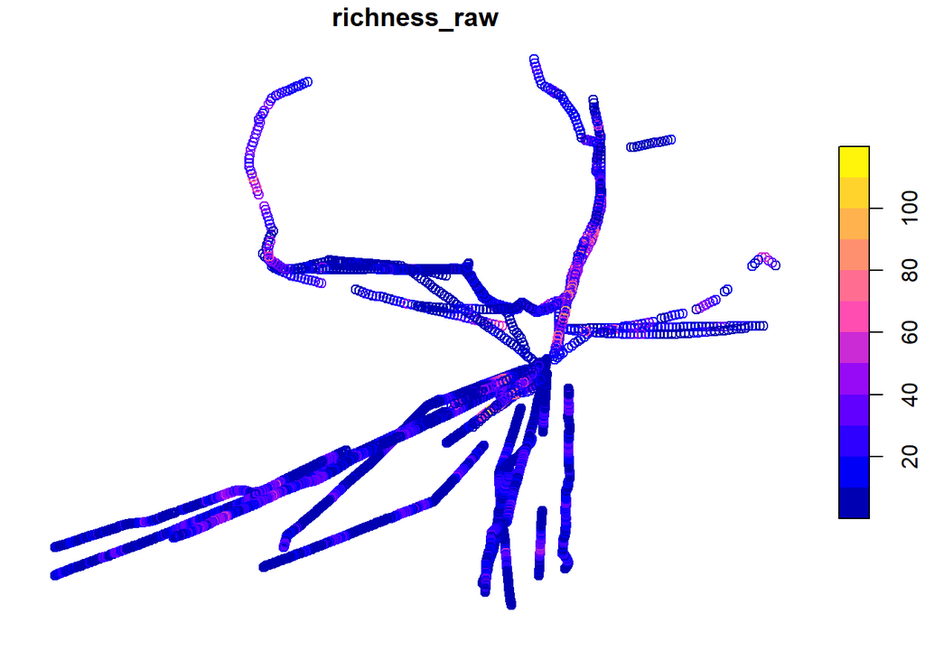

```r
plot(sdat["richness_raw"])
```

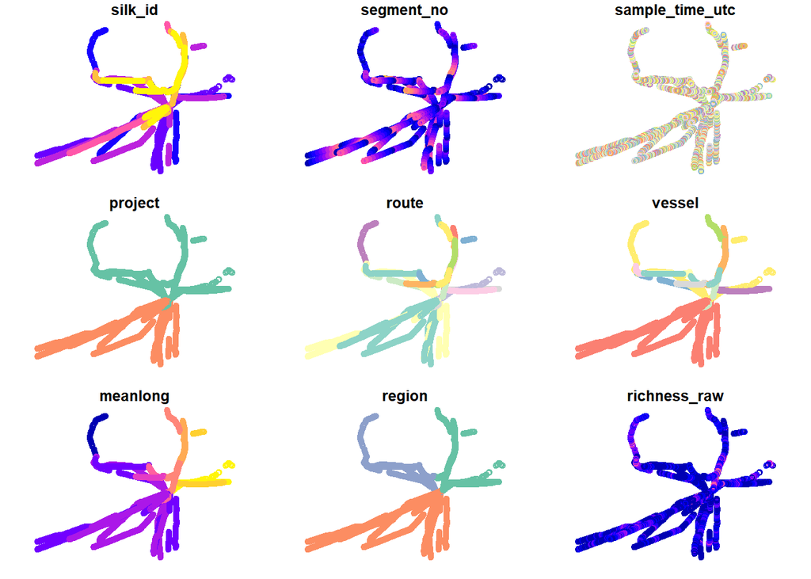

```r
plot(sdat)
```

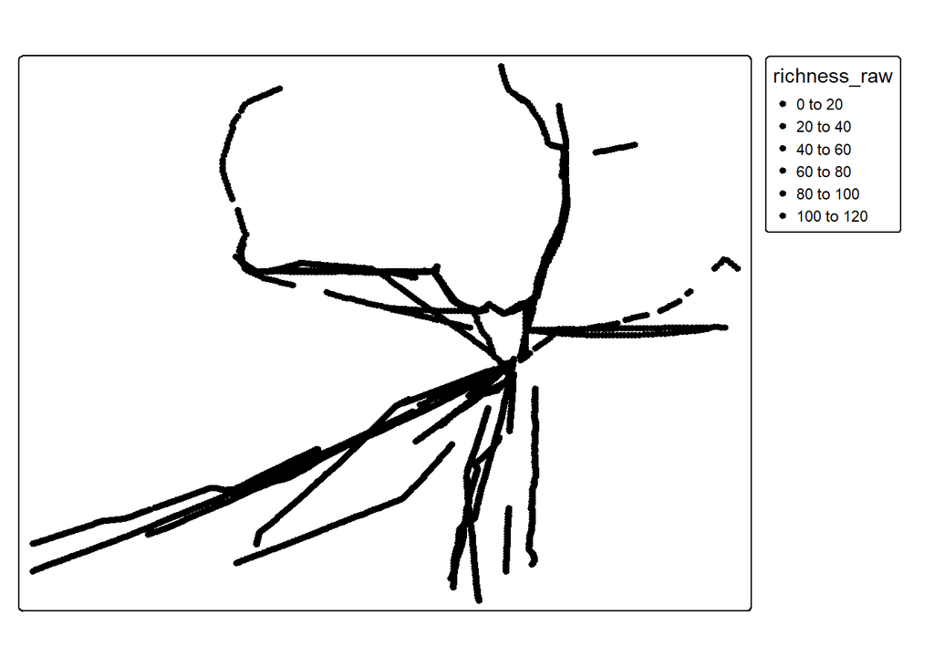

```r
tm_shape(sdat)+
  tm_dots(col = "richness_raw")
```

```r
#tmap_save(tm1,filename = "richness-map.png",
         #width = 600, heights = 600)
# cant get the above tm1 to work, I do not uderstand where it is coming from COME BACK
```

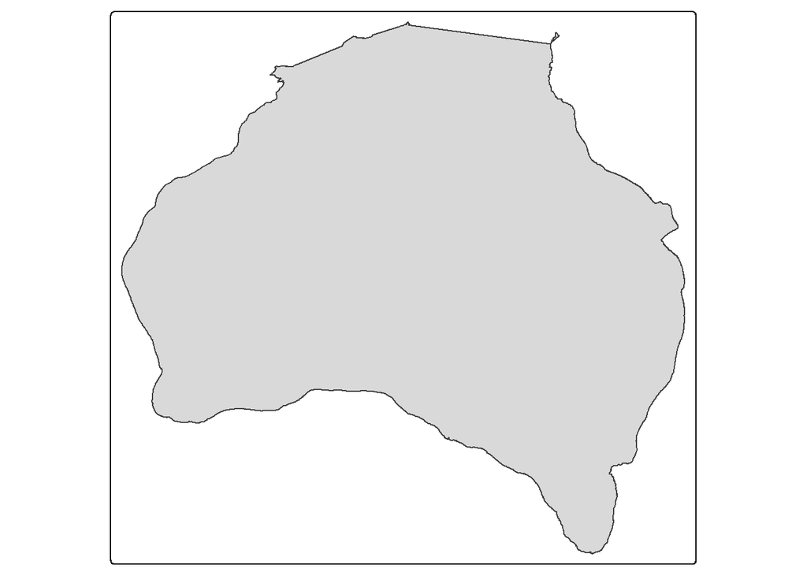

```r
aus <- st_read("C:/Users/sydne/OneDrive - James Cook University/Documents/JCU/MB5370/github/SR-Code/Module04_SR/data/data-for-course/spatial-data/Aussie/Aussie.shp")
shelf <- st_read("C:/Users/sydne/OneDrive - James Cook University/Documents/JCU/MB5370/github/SR-Code/Module04_SR/data/data-for-course/spatial-data/aus_shelf/aus_shelf.shp")
tm_shape(shelf)+
  tm_polygons()
```

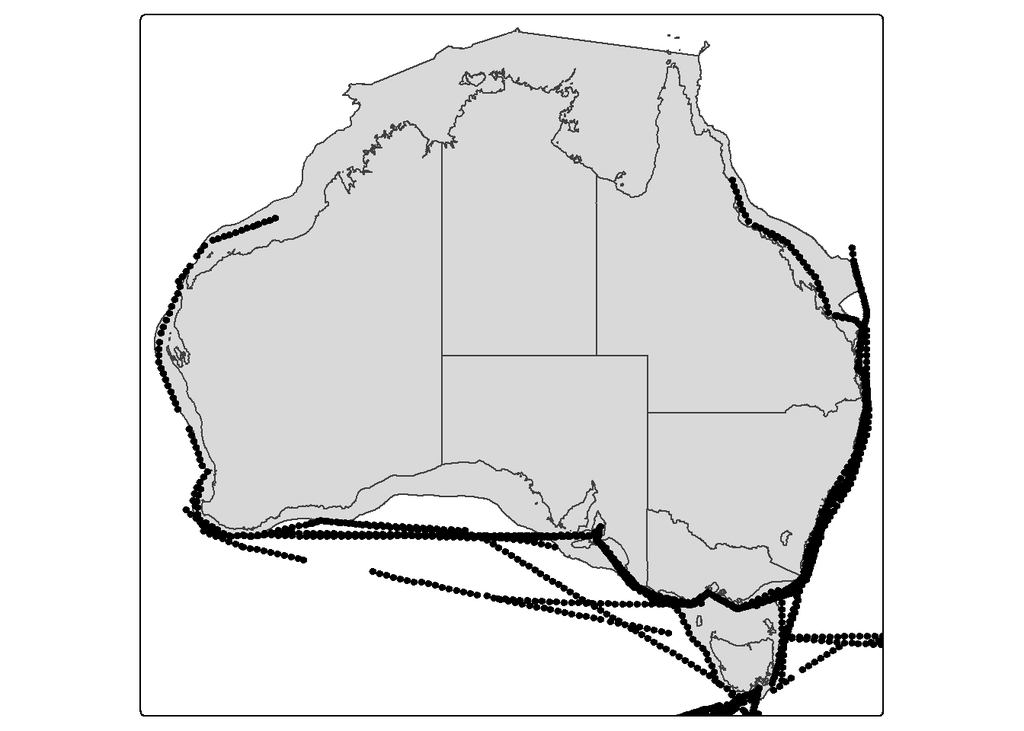

```r
tm_shape(shelf, box = sdat)+
  tm_polygons()+
  tm_shape(aus)+
  tm_polygons()+
  tm_shape(sdat)+
  tm_dots()
```